# Visualización de datos del Covid-19

Bryan Velicka Leka y Franco Manuel García Dos Santos

2021-04-30

## ———————— Introducción ————————

En este documento preprocesaremos, analizaremos y visualizaremos datos sobre el covid-19 tomados hasta la fecha.

## ———————— Paso 1 –> Preprocesado ————————

### 1. Paquetes y librerias que vamos a utilizar. Importamos dataset covid_19_data.csv

```r
#install.packages("ggthemes")
library(tidyverse)
library(dplyr)
library(ggplot2)
library(ggthemes)
library(readr)
library(gcookbook)
covid_19_data <- read_csv("covid_19_data.csv")
#View(covid_19_data)
```

### 2. Seleccion de columnas y primeras transformaciones

```r
#Solo nos quedamos con las columnas 'ObservationDate', 'Country/Region', 'Confirmed', 'Deaths' y 'Recovery'
datacovid19 <- covid_19_data %>%
                 select(-c(1,3,5))

#Transformo los valores de la columna 'Pais-Region': "Mainland China" lo transformo a "China", y "occupied Palestinian territory" a "Palestina".
ind_c <- which(datacovid19$`Country/Region`=="Mainland China")
ind_p <- which(datacovid19$`Country/Region`=="occupied Palestinian territory")

datacovid19$`Country/Region`[ind_c] <- "China"
datacovid19$`Country/Region`[ind_p] <- "Palestina"

datacovid19
```

```
## # A tibble: 236,017 x 5
##    ObservationDate `Country/Region` Confirmed Deaths Recovered
##    <chr>           <chr>                <dbl>  <dbl>     <dbl>
##  1 01/22/2020      China                    1      0         0
##  2 01/22/2020      China                   14      0         0
##  3 01/22/2020      China                    6      0         0
##  4 01/22/2020      China                    1      0         0
##  5 01/22/2020      China                    0      0         0
##  6 01/22/2020      China                   26      0         0
##  7 01/22/2020      China                    2      0         0
##  8 01/22/2020      China                    1      0         0
##  9 01/22/2020      China                    4      0         0
## 10 01/22/2020      China                    1      0         0
## # ... with 236,007 more rows
```

```r
#Agrupo por 'Pais-Region' y 'ObservationDate' y calculo la cuenta de confirmados, muertos y recuperados por dia
datacovid19_por_dia <- datacovid19 %>%
                       group_by(`Country/Region`, ObservationDate) %>%
                       summarise_at(c("Confirmed", "Deaths", "Recovered"), sum)

datacovid19_por_dia
```

```
## # A tibble: 69,085 x 5
## # Groups:   Country/Region [226]
##    `Country/Region` ObservationDate Confirmed Deaths Recovered
##    <chr>            <chr>               <dbl>  <dbl>     <dbl>
##  1 ('St. Martin',)  03/10/2020              2      0         0
##  2 Afghanistan      01/01/2021          51526   2191     41727
##  3 Afghanistan      01/02/2021          51526   2191     41727
##  4 Afghanistan      01/03/2021          51526   2191     41727
##  5 Afghanistan      01/04/2021          53011   2237     42530
##  6 Afghanistan      01/05/2021          53105   2244     42666
##  7 Afghanistan      01/06/2021          53105   2244     42666
##  8 Afghanistan      01/07/2021          53207   2253     43291
##  9 Afghanistan      01/08/2021          53332   2257     43440
## 10 Afghanistan      01/09/2021          53400   2264     43740
## # ... with 69,075 more rows
```

### 3.Conversión de la columna ‘ObservationDate’ en columna llamada ‘Date’ (tipo Date). Obtener los datos del covid en España

```r
#Esta función separa el dia, mes y año y convierte 'ObservationDate' a tipo Date. Devuelve el dataset con dicha columna ya convertida y las columnas extras
convertir_a_fecha <- function(ds){

  getAño <- function(x){
    strsplit(x,"/")[[1]][[3]]
  }
  getMes <- function(x){
    strsplit(x,"/")[[1]][[1]]
  }
  getDia <- function(x){
    strsplit(x,"/")[[1]][[2]]
  }

  ds$año <- sapply(ds$ObservationDate, getAño)
  ds$mes <- sapply(ds$ObservationDate, getMes)
  ds$dia <- sapply(ds$ObservationDate, getDia)

  ds$ObservationDate <-
      as.Date( paste(ds$año,ds$mes,ds$dia, sep = "-") , "%Y-%m-%d")

  return(ds)

}

#------------------------------------------------------------------------#
#Nos quedamos con los datos del covid en España
datacovid19_por_dia_Spain <- datacovid19_por_dia %>%
                            filter( `Country/Region`=="Spain" )

#Convertimos la columna 'ObservationDate' a tipo Date
datacovid19_por_dia_Spain <- convertir_a_fecha(datacovid19_por_dia_Spain)

#Agrupamos y ordenamos por Fecha y eliminamos columnas que no nos interesan
datacovid19_por_dia_Spain <- datacovid19_por_dia_Spain %>%
                             group_by(ObservationDate) %>%
                             arrange(ObservationDate) %>%
                             select(-c(1,6,7,8))

#Renombramos nombre de columnas para mayor facilidad
names(datacovid19_por_dia_Spain)[1:4] <-
c("Date","Confirmados","Fallecimientos","Recuperados")

datacovid19_por_dia_Spain
```

```
## # A tibble: 393 x 4
## # Groups:   Date [393]
##    Date       Confirmados Fallecimientos Recuperados
##    <date>           <dbl>          <dbl>       <dbl>
##  1 2020-02-01           1              0           0
##  2 2020-02-02           1              0           0
##  3 2020-02-03           1              0           0
##  4 2020-02-04           1              0           0
##  5 2020-02-05           1              0           0
##  6 2020-02-06           1              0           0
##  7 2020-02-07           1              0           0
##  8 2020-02-08           1              0           0
##  9 2020-02-09           2              0           0
## 10 2020-02-10           2              0           0
## # ... with 383 more rows
```

## ———————— Paso 2 –> Visualización ————————

### 1. Visualizar las defunciones, los casos confirmados, y los recuperados por día en España (acumulados)

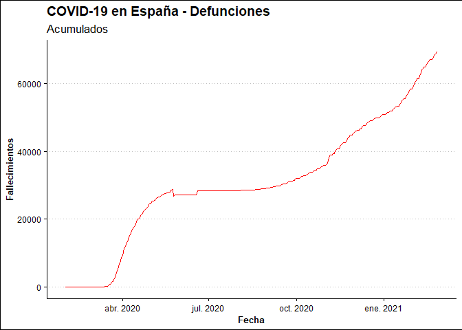

```r
g1 <- ggplot(datacovid19_por_dia_Spain)
g1 + geom_line(aes(x=Date, y=Fallecimientos), color="red") +
  labs(x = "Fecha", y="Fallecimientos") +
  ggtitle("COVID-19 en España - Defunciones", "Acumulados") +
  theme_clean() +
  theme( axis.title = element_text(size = 10, face = "bold") )
```

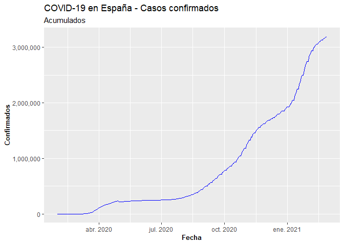

```r
g2 <- ggplot(datacovid19_por_dia_Spain)
g2 + geom_line(aes(x=Date, y=Confirmados), color="blue") +
  labs(x = "Fecha", y="Confirmados") +
  ggtitle("COVID-19 en España - Casos confirmados", "Acumulados") +
  theme_grey() +
  scale_y_continuous(labels = scales::comma) +
  theme( axis.title = element_text(size = 10, face = "bold") )
```

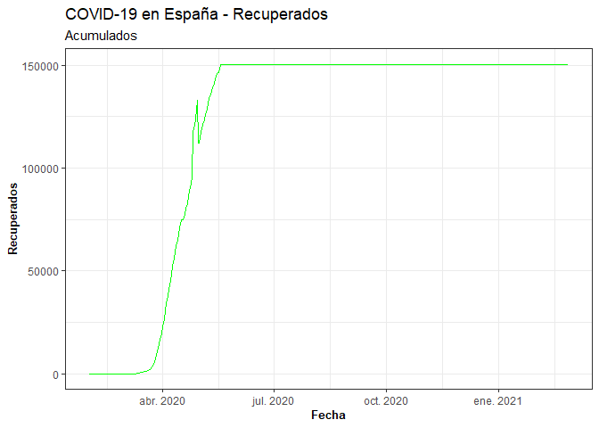

```r
g3 <- ggplot(datacovid19_por_dia_Spain)
g3 + geom_line(aes(x=Date, y=Recuperados), color="green") +
  labs(x = "Fecha", y="Recuperados") +
  ggtitle("COVID-19 en España - Recuperados", "Acumulados") +
  theme_bw() +
  theme( axis.title = element_text(size = 10, face = "bold") )
```

### 2. Visualizar los casos acumulados en cada mes desde que comenzó la pandemia en China.

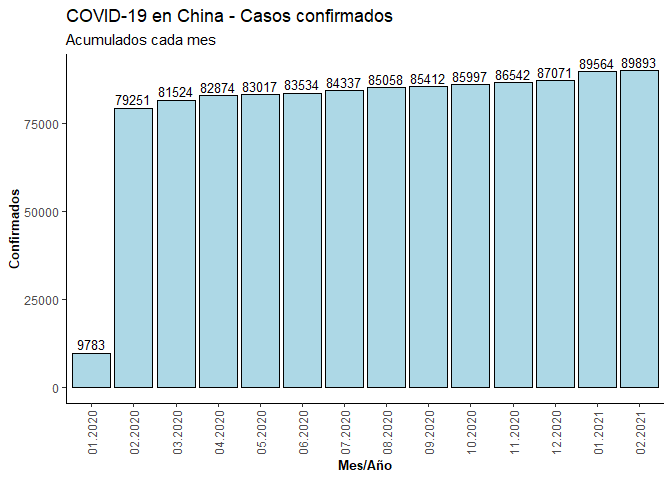

```r
datacovid19_por_dia_China <- datacovid19_por_dia %>%
                            filter( `Country/Region`=="China" )


datacovid19_por_dia_China <- convertir_a_fecha(datacovid19_por_dia_China)

datacovid19_por_dia_China <- datacovid19_por_dia_China %>%
    group_by(año, mes) %>%
    arrange(año) %>%
    summarise_at(c("Confirmed"), max)


g4 <- ggplot(datacovid19_por_dia_China,aes(x=interaction(mes,año), y=Confirmed))
g4 + geom_bar(stat="identity", fill="lightblue", colour="black") +
geom_text(aes(label=Confirmed), vjust=-0.3, colour="black", size = 3.5) + theme_classic() +
ggtitle("COVID-19 en China - Casos confirmados", "Acumulados cada mes") +
labs(x = "Mes/Año", y="Confirmados") +
theme(axis.text.x = element_text(angle = 90, vjust = 0.5),
      axis.title = element_text(size = 10, face = "bold") )
```

### 3. Obtener una tabla con los los 20 paises con más fallecimientos y visualizar:

```r
fallecidos_totales_por_pais <- datacovid19_por_dia %>%
  group_by(`Country/Region`) %>%
  summarise_at(c("Confirmed", "Deaths", "Recovered"), max) %>%
  arrange(desc(Deaths)) %>%
  filter(row_number()<=20)

fallecidos_totales_por_pais
```

```
## # A tibble: 20 x 4
##    `Country/Region` Confirmed Deaths Recovered
##    <chr>                <dbl>  <dbl>     <dbl>
##  1 US                28554465 511994   6399531
##  2 Brazil            10517232 254221   9371448
##  3 Mexico             2084128 185257   1630002
##  4 India             11096731 157051  10775169
##  5 UK                 4182772 122939     11602
##  6 Italy              2907825  97507   2398352
##  7 France             3747263  85741    261649
##  8 Russia             4187166  84330   3756808
##  9 Germany            2444177  70092   2252970
## 10 Spain              3188553  69142    150376
## 11 Iran               1623159  59980   1386534
## 12 Colombia           2248135  59660   2145450
## 13 Argentina          2104197  51946   1899087
## 14 South Africa       1512225  49941   1429047
## 15 Peru               1323863  46299   1225995
## 16 Poland             1696885  43656   1414461
## 17 Indonesia          1329074  35981   1136054
## 18 Turkey             2693164  28503   2565723
## 19 Ukraine            1389570  27306   1210919
## 20 Belgium             769414  22052     31130
```

#### 3.1. fallecimientos acumulados, contagios acumulados y recuperaciones acumuladas para estos 20 paises

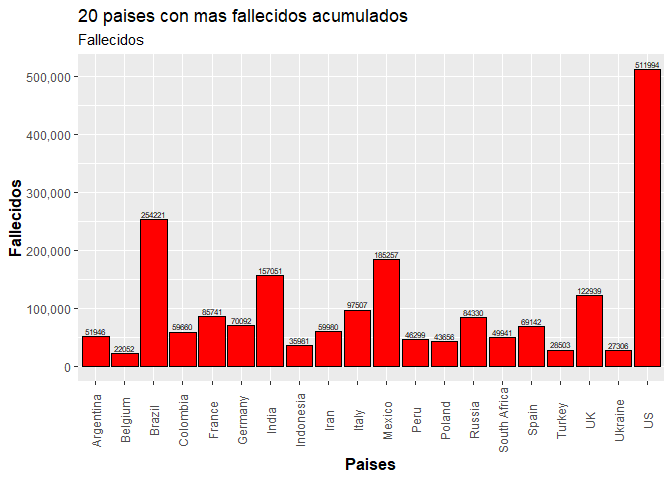

```r
g5 <- ggplot(fallecidos_totales_por_pais,aes(x=`Country/Region`, y=Deaths)) +
      geom_bar(stat="identity", fill="red", colour="black") +
      theme(axis.text.x = element_text(angle = 90, vjust = 0.5),
      axis.title = element_text(size = 12, face = "bold") ) +
      ggtitle("20 paises con mas fallecidos acumulados", "Fallecidos") +
      labs(x = "Paises", y="Fallecidos") +
      scale_y_continuous(labels = scales::comma) +
      geom_text(aes(label=Deaths), vjust=-0.3, colour="black", size = 2.2)

g5
```

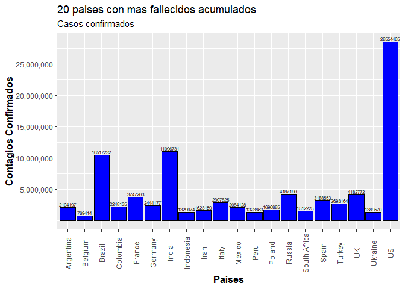

```r
g6 <- ggplot(fallecidos_totales_por_pais,aes(x=`Country/Region`, y=Confirmed)) +
      geom_bar(stat="identity", fill="blue", colour="black") +
      theme(axis.text.x = element_text(angle = 90, vjust = 0.5),
      axis.title = element_text(size = 12, face = "bold") ) +
      ggtitle("20 paises con mas fallecidos acumulados", "Casos confirmados") +
      labs(x = "Paises", y="Contagios Confirmados") +
      scale_y_continuous(labels = scales::comma, breaks = seq(5000000,25000000, by=5000000 )) +
      geom_text(aes(label=Confirmed), vjust=-0.3, colour="black", size = 2.2)

g6
```

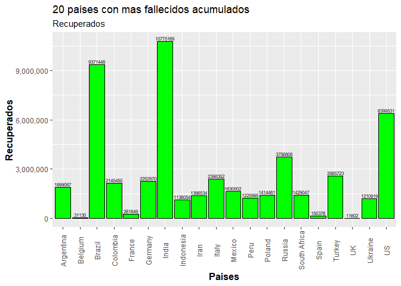

```r
g7 <- ggplot(fallecidos_totales_por_pais,aes(x=`Country/Region`, y=Recovered)) +
      geom_bar(stat="identity", fill="green", colour="black") +
      theme(axis.text.x = element_text(angle = 90, vjust = 0.5),
      axis.title = element_text(size = 12, face = "bold") ) +
      ggtitle("20 paises con mas fallecidos acumulados", "Recuperados") +
      labs(x = "Paises", y="Recuperados") +
      scale_y_continuous(labels = scales::comma) +
      geom_text(aes(label=Recovered), vjust=-0.3, colour="black", size = 2.2)

g7
```

#### 3.2. Evolución para estos 20 paises de los fallecimientos en la misma gráfica

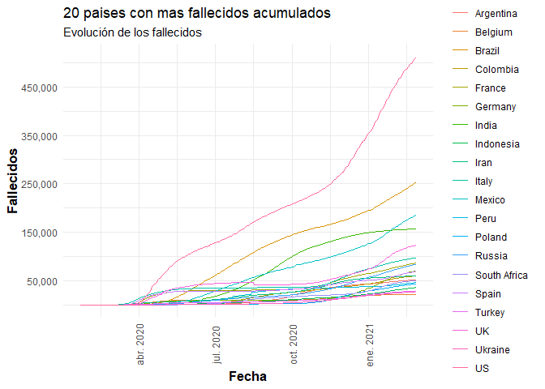

```r
datacovid19_por_dia2 <- datacovid19_por_dia %>%
  filter(`Country/Region` %in% fallecidos_totales_por_pais$`Country/Region`) %>%
  convertir_a_fecha() %>%
  group_by(`Country/Region`) %>%
  arrange(`Country/Region`, ObservationDate)


g8 <- ggplot(datacovid19_por_dia2, aes(x=ObservationDate, y=Deaths, group=`Country/Region`)) +
      geom_line(aes(color = `Country/Region`))  +
      #facet_wrap(~`Country/Region`, ncol = 5) +
      theme_minimal() +
      theme(axis.text.x = element_text(angle = 90, vjust = 0.5), axis.title = element_text(size = 13, face = "bold") ) +
      ggtitle("20 paises con mas fallecidos acumulados", "Evolución de los fallecidos") +
      labs(x = "Fecha", y="Fallecidos") +
      scale_y_continuous(labels = scales::comma, breaks = seq(50000,750000, by=100000 ))

g8
```

#### 3.3. Evolución para estos 20 paises de los contagios en la misma gráfica

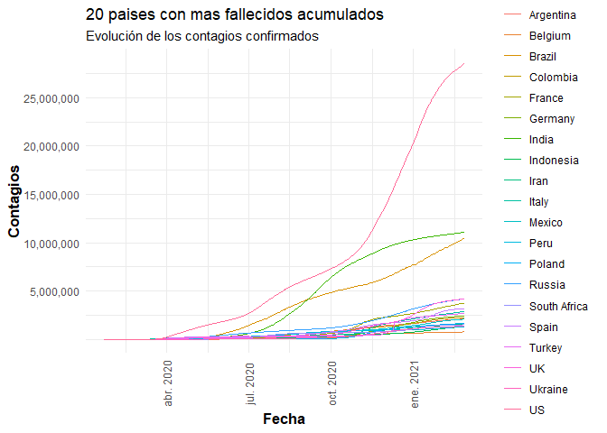

```r
g9 <- ggplot(datacovid19_por_dia2, aes(x=ObservationDate, y=Confirmed, group=`Country/Region`)) +
      geom_line(aes(color = `Country/Region`))  +
      #facet_wrap(~`Country/Region`, ncol = 5) +
      theme_minimal() +
      theme(axis.text.x = element_text(angle = 90, vjust = 0.5), axis.title = element_text(size = 13, face = "bold") ) +
      ggtitle("20 paises con mas fallecidos acumulados", "Evolución de los contagios confirmados") +
      labs(x = "Fecha", y="Contagios") +
      scale_y_continuous(labels = scales::comma, breaks = seq(5000000,50000000, by=5000000 ))

g9
```

### 4. Apartado libre

#### Evolución de las muertes por Covid19 en España durante el principio de la misma y el efecto de la cuarentena domiciliaria.

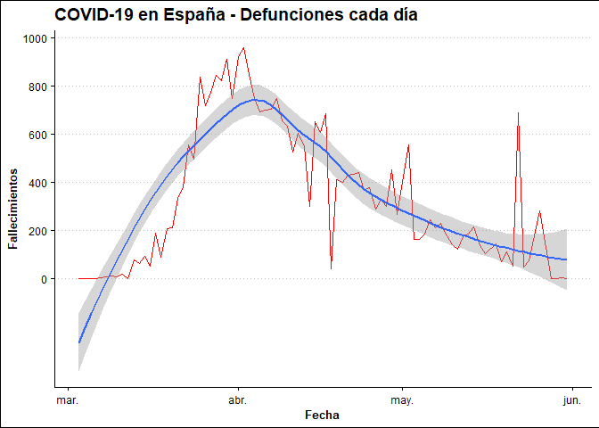

```r
#Filtramos los datos hasta el primer dia de Junio (no incluido)
covid_dia_spain_noAcuml <- datacovid19_por_dia_Spain %>%
  filter(Date < "2020-06-01")

#Añado nueva columna para llevar la cuenta de muertes por dia (no acumulada)
covid_dia_spain_noAcuml$FallNoAcuml <- 0

#Calculo el numero de muertes por dia
for(i in 2:length(covid_dia_spain_noAcuml$Fallecimientos)) {

  covid_dia_spain_noAcuml $FallNoAcuml[i] =
                    covid_dia_spain_noAcuml$Fallecimientos[i] -
                    covid_dia_spain_noAcuml$Fallecimientos[i-1]

}

#Me deshago de los valores negativos (esto ocurre cuando en la cuenta acumulada de muertes, se han contabilizado erroneamente menos numeros que el real y lo corriguen luego)
covid_dia_spain_noAcuml  <- covid_dia_spain_noAcuml  %>%
                            filter(FallNoAcuml > 0)

g1 <- ggplot(covid_dia_spain_noAcuml )
g1 + geom_line(aes(x=Date, y=FallNoAcuml), color="red") +
  labs(x = "Fecha", y="Fallecimientos") +
  ggtitle("COVID-19 en España - Defunciones cada día") +
  theme_clean() +
  theme( axis.title = element_text(size = 10, face = "bold") ) +
  geom_smooth(aes(x=Date, y=FallNoAcuml)) +
  scale_y_continuous(breaks = seq(0,2000, by=200 ))
```

```r
#Podemos observar como a mitades de Marzo el covid19 hizo una mayor presencia, disparando las muertes por dicho virus de manera exponencial, llegando al pico a principios de Abril.
#Tras la medida tomada por el gobierno del confinamiento domiciliario, ¿qué efecto tuvo esto con respecto las muertes por covid19?
#Podemos ver como a partir de principios de Abril, las muertes sufren un descenso importante, haciendo que la curva de fallecimientos vaya bajando y se controle la situación hospitalaria.
#Conclusión: El confinamiento ha resultado ser una medida muy acertada, a pesar de que provocó ciertas situaciones sociales y psicológicas para la población española. Minimizar las muertes era clave para qué, los hospitales tuvieran menos carga de trabajo y, el efecto tras el covid19 sean los menores posibles.
```

#### Evolución de los contagios y fallecidos de covid en las distintas comunidadaes autonomas de España

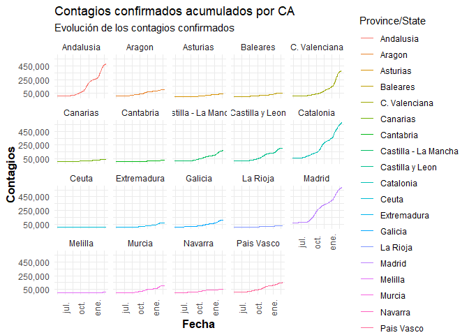

```r
datoscovidProvincias <- covid_19_data %>%
  filter(`Country/Region`=="Spain" & !is.na(`Province/State`) & `Province/State`!="Unknown") %>%
  select(-c(1,5)) %>%
  convertir_a_fecha()%>%
  group_by(`Province/State`, ObservationDate) %>%
  arrange(`Province/State`, ObservationDate)


datoscovidProvinciasAcumulado <- datoscovidProvincias  %>%
  summarise_at(c("Confirmed", "Deaths", "Recovered"), sum)


g10 <- ggplot(datoscovidProvinciasAcumulado, aes(x=ObservationDate, y=Confirmed, group=`Province/State`)) +
      geom_line(aes(color = `Province/State`))  +
      facet_wrap(~`Province/State`, ncol = 5) +
      theme_minimal() +
      theme(axis.text.x = element_text(angle = 90, vjust = 0.5), axis.title = element_text(size = 13, face = "bold") ) +
      ggtitle("Contagios confirmados acumulados por CA", "Evolución de los contagios confirmados") +
      labs(x = "Fecha", y="Contagios") +
      scale_y_continuous(labels = scales::comma, breaks = seq(50000,800000, by=200000 ))

g10
```

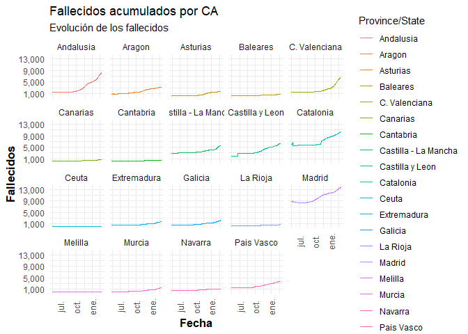

```r
g11 <- ggplot(datoscovidProvinciasAcumulado, aes(x=ObservationDate, y=Deaths, group=`Province/State`)) +
      geom_line(aes(color = `Province/State`))  +
      facet_wrap(~`Province/State`, ncol = 5) +
      theme_minimal() +
      theme(axis.text.x = element_text(angle = 90, vjust = 0.5), axis.title = element_text(size = 13, face = "bold") ) +
      ggtitle("Fallecidos acumulados por CA", "Evolución de los fallecidos") +
      labs(x = "Fecha", y="Fallecidos") +
      scale_y_continuous(labels = scales::comma, breaks = seq(1000,15000, by=4000 ))

g11
```

#### Fallecidos totales de covid y casos confirmados en las distintas comunidades autonomas de España

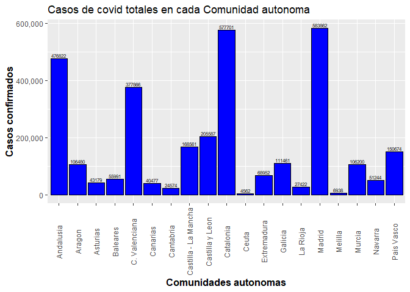

```r
fallecidos_totales_por_CC <- datoscovidProvincias %>%
  group_by(`Province/State`) %>%
  summarise_at(c("Confirmed", "Deaths", "Recovered"), max) %>%
  arrange(desc(Deaths))



g12 <- ggplot(fallecidos_totales_por_CC, aes(x=`Province/State`, y=Confirmed)) +
      geom_bar(stat="identity", fill="blue", colour="black") +
      theme(axis.text.x = element_text(angle = 90, vjust = 0.5),
      axis.title = element_text(size = 12, face = "bold") ) +
      ggtitle("Casos de covid totales en cada Comunidad autonoma") +
      labs(x = "Comunidades autonomas", y="Casos confirmados") +
      scale_y_continuous(labels = scales::comma) +
      geom_text(aes(label=Confirmed), vjust=-0.3, colour="black", size = 2.2)

g12
```

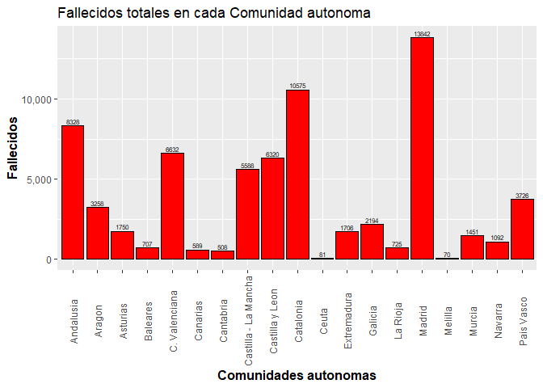

```r
g13 <- ggplot(fallecidos_totales_por_CC, aes(x=`Province/State`, y=Deaths)) +
      geom_bar(stat="identity", fill="red", colour="black") +
      theme(axis.text.x = element_text(angle = 90, vjust = 0.5),
      axis.title = element_text(size = 12, face = "bold") ) +
      ggtitle("Fallecidos totales en cada Comunidad autonoma") +
      labs(x = "Comunidades autonomas", y="Fallecidos") +
      scale_y_continuous(labels = scales::comma) +
      geom_text(aes(label=Deaths), vjust=-0.3, colour="black", size = 2.2)

g13
```

```r
#Con las gráficas anteriores es posible ver el efecto de las medidas tomadas por cada
#comunidad autonoma durante y después de la cuarentena. Son especialmente interesantes
#las CC con mayor población como Madrid, Andalucía y Cataluña con las que se puede
#ver que las medidas más duras tomadas en Andalucia o cataluña respecto a Madrid han
#hecho que el ratio de fallecidos por contagio es menor.
```